# Analysis - Speech Prosody

Tom Offrede

2023-11-27

# Notes

- The first section of this file contains only the significant findings, and the second half, only null-results. (Exception: all f0 results are in the “significant” section.)

# ONLY SIGNIFICANT FINDINGS

# SPEECH ANALYSIS

## Speech adaptation (regardless of interlocutor)

### Numerical measure (all speakers together; without Domino task)

#### f0 median

- Only during question lists: f0 median decreases only in the close condition (already with random slopes for turn per participant!)

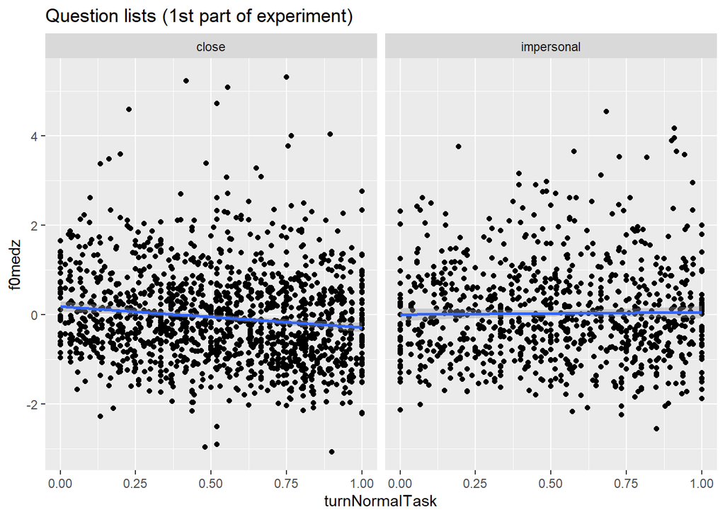

```r
ggplot(ipus |> filter(task=="Lists"), aes(turnNormalTask, f0medz))+
  geom_point()+
  geom_smooth(method="lm")+
  facet_wrap(~condition)+
  ggtitle("Question lists (1st part of experiment)")
```

```r
summary(m <- lmer(f0medz ~ turnNormalTask + (1+turnNormalTask|speaker), ipus |> filter(task=="Lists")))
```

```
## Linear mixed model fit by REML. t-tests use Satterthwaite's method [
## lmerModLmerTest]
## Formula: f0medz ~ turnNormalTask + (1 + turnNormalTask | speaker)
##    Data: filter(ipus, task == "Lists")
##
## REML criterion at convergence: 6726.4
##
## Scaled residuals:
##     Min      1Q  Median      3Q     Max
## -3.0249 -0.6999 -0.1174  0.5502  5.2236
##
## Random effects:
##  Groups   Name           Variance Std.Dev. Corr
##  speaker  (Intercept)    0.0734   0.2709
##           turnNormalTask 0.2288   0.4784   -0.66
##  Residual                1.0508   1.0251
## Number of obs: 2302, groups:  speaker, 38
##
## Fixed effects:
##                Estimate Std. Error       df t value Pr(>|t|)
## (Intercept)     0.10144    0.06385 34.86159   1.589   0.1212
## turnNormalTask -0.25758    0.10914 38.91859  -2.360   0.0234 *
## ---
## Signif. codes:  0 '***' 0.001 '**' 0.01 '*' 0.05 '.' 0.1 ' ' 1
##
## Correlation of Fixed Effects:
##             (Intr)
## turnNrmlTsk -0.768
```

```r
summary(m1 <- lmer(f0medz ~ turnNormalTask : condition + (1+turnNormalTask|speaker), ipus |> filter(task=="Lists")))
```

```
## Linear mixed model fit by REML. t-tests use Satterthwaite's method [
## lmerModLmerTest]
## Formula: f0medz ~ turnNormalTask:condition + (1 + turnNormalTask | speaker)
##    Data: filter(ipus, task == "Lists")
##
## REML criterion at convergence: 6724.5
##
## Scaled residuals:
##     Min      1Q  Median      3Q     Max
## -2.9693 -0.7008 -0.1207  0.5506  5.2583
##
## Random effects:
##  Groups   Name           Variance Std.Dev. Corr
##  speaker  (Intercept)    0.07411  0.2722
##           turnNormalTask 0.17739  0.4212   -0.62
##  Residual                1.05080  1.0251
## Number of obs: 2302, groups:  speaker, 38
##
## Fixed effects:
##                                    Estimate Std. Error       df t value
## (Intercept)                         0.09777    0.06398 34.88603   1.528
## turnNormalTask:conditionclose      -0.38092    0.11799 42.20195  -3.228
## turnNormalTask:conditionimpersonal -0.09402    0.12800 57.93609  -0.735
##                                    Pr(>|t|)
## (Intercept)                         0.13549
## turnNormalTask:conditionclose       0.00241 **
## turnNormalTask:conditionimpersonal  0.46558
## ---
## Signif. codes:  0 '***' 0.001 '**' 0.01 '*' 0.05 '.' 0.1 ' ' 1
##
## Correlation of Fixed Effects:
##                   (Intr) trnNrmlTsk:cndtnc
## trnNrmlTsk:cndtnc -0.650
## trnNrmlTsk:cndtnm -0.617  0.401
```

```r
anova(m, m1)
```

```
## refitting model(s) with ML (instead of REML)
```

```
## Data: filter(ipus, task == "Lists")
## Models:
## m: f0medz ~ turnNormalTask + (1 + turnNormalTask | speaker)
## m1: f0medz ~ turnNormalTask:condition + (1 + turnNormalTask | speaker)
##    npar    AIC    BIC  logLik deviance Chisq Df Pr(>Chisq)
## m     6 6731.2 6765.7 -3359.6   6719.2
## m1    7 6729.1 6769.2 -3357.5   6715.1 4.151  1    0.04161 *
## ---
## Signif. codes:  0 '***' 0.001 '**' 0.01 '*' 0.05 '.' 0.1 ' ' 1
```

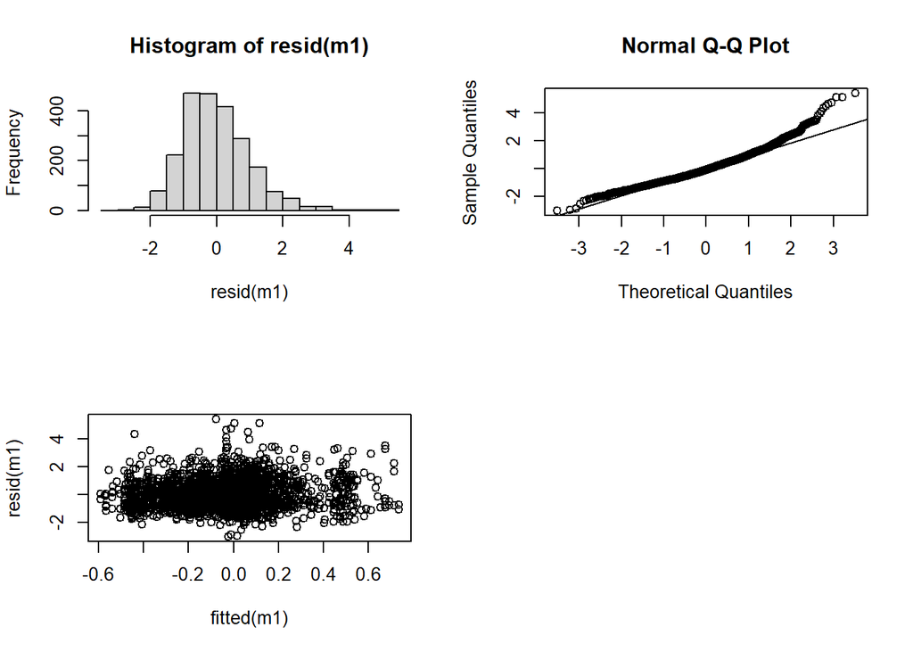

```r
par(mfrow=c(2, 2))
hist(resid(m1))
qqnorm(resid(m1));qqline(resid(m1))
plot(fitted(m1), resid(m1))
```

#### f0 SD

- Only during question lists: f0 SD decreases only in close condition.

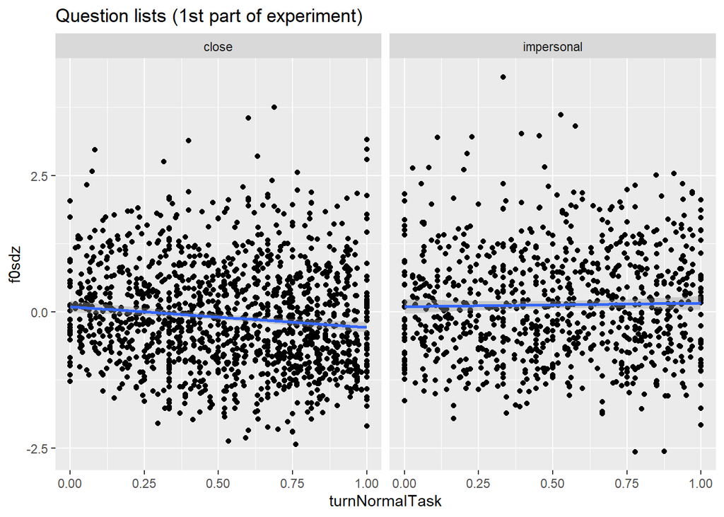

```r
ggplot(ipus |> filter(task=="Lists"), aes(turnNormalTask, f0sdz))+
  geom_point()+
  geom_smooth(method="lm")+
  facet_wrap(~condition)+
  ggtitle("Question lists (1st part of experiment)")
```

```r
summary(m <- lmer(f0sdz ~ turnNormalTask + (1+turnNormalTask|speaker), ipus |> filter(task=="Lists")))
```

```
## Linear mixed model fit by REML. t-tests use Satterthwaite's method [
## lmerModLmerTest]
## Formula: f0sdz ~ turnNormalTask + (1 + turnNormalTask | speaker)
##    Data: filter(ipus, task == "Lists")
##
## REML criterion at convergence: 6182.8
##
## Scaled residuals:
##     Min      1Q  Median      3Q     Max
## -3.0706 -0.6897 -0.0465  0.6232  4.0804
##
## Random effects:
##  Groups   Name           Variance Std.Dev. Corr
##  speaker  (Intercept)    0.08014  0.2831
##           turnNormalTask 0.04798  0.2190   0.06
##  Residual                0.84639  0.9200
## Number of obs: 2281, groups:  speaker, 38
##
## Fixed effects:
##                Estimate Std. Error       df t value Pr(>|t|)
## (Intercept)     0.10640    0.06178 36.70516   1.722   0.0934 .
## turnNormalTask -0.18734    0.07675 36.31513  -2.441   0.0197 *
## ---
## Signif. codes:  0 '***' 0.001 '**' 0.01 '*' 0.05 '.' 0.1 ' ' 1
##
## Correlation of Fixed Effects:
##             (Intr)
## turnNrmlTsk -0.494
```

```r
summary(m1 <- lmer(f0sdz ~ turnNormalTask : condition + (1+turnNormalTask|speaker), ipus |> filter(task=="Lists")))
```

```
## Linear mixed model fit by REML. t-tests use Satterthwaite's method [
## lmerModLmerTest]
## Formula: f0sdz ~ turnNormalTask:condition + (1 + turnNormalTask | speaker)
##    Data: filter(ipus, task == "Lists")
##
## REML criterion at convergence: 6168
##
## Scaled residuals:
##     Min      1Q  Median      3Q     Max
## -3.1133 -0.6883 -0.0473  0.6219  4.1135
##
## Random effects:
##  Groups   Name           Variance  Std.Dev. Corr
##  speaker  (Intercept)    8.847e-02 0.297435
##           turnNormalTask 6.341e-05 0.007963 -1.00
##  Residual                8.446e-01 0.919044
## Number of obs: 2281, groups:  speaker, 38
##
## Fixed effects:
##                                     Estimate Std. Error        df t value
## (Intercept)                          0.09681    0.06345  41.34096   1.526
## turnNormalTask:conditionclose       -0.40020    0.08051 409.50488  -4.971
## turnNormalTask:conditionimpersonal   0.10393    0.09508 349.44976   1.093
##                                    Pr(>|t|)
## (Intercept)                           0.135
## turnNormalTask:conditionclose      9.82e-07 ***
## turnNormalTask:conditionimpersonal    0.275
## ---
## Signif. codes:  0 '***' 0.001 '**' 0.01 '*' 0.05 '.' 0.1 ' ' 1
##
## Correlation of Fixed Effects:
##                   (Intr) trnNrmlTsk:cndtnc
## trnNrmlTsk:cndtnc -0.455
## trnNrmlTsk:cndtnm -0.443  0.201
```

```r
anova(m, m1)
```

```
## refitting model(s) with ML (instead of REML)
```

```
## Data: filter(ipus, task == "Lists")
## Models:
## m: f0sdz ~ turnNormalTask + (1 + turnNormalTask | speaker)
## m1: f0sdz ~ turnNormalTask:condition + (1 + turnNormalTask | speaker)
##    npar    AIC    BIC  logLik deviance  Chisq Df Pr(>Chisq)
## m     6 6187.5 6221.9 -3087.8   6175.5
## m1    7 6171.8 6211.9 -3078.9   6157.8 17.708  1  2.576e-05 ***
## ---
## Signif. codes:  0 '***' 0.001 '**' 0.01 '*' 0.05 '.' 0.1 ' ' 1
```

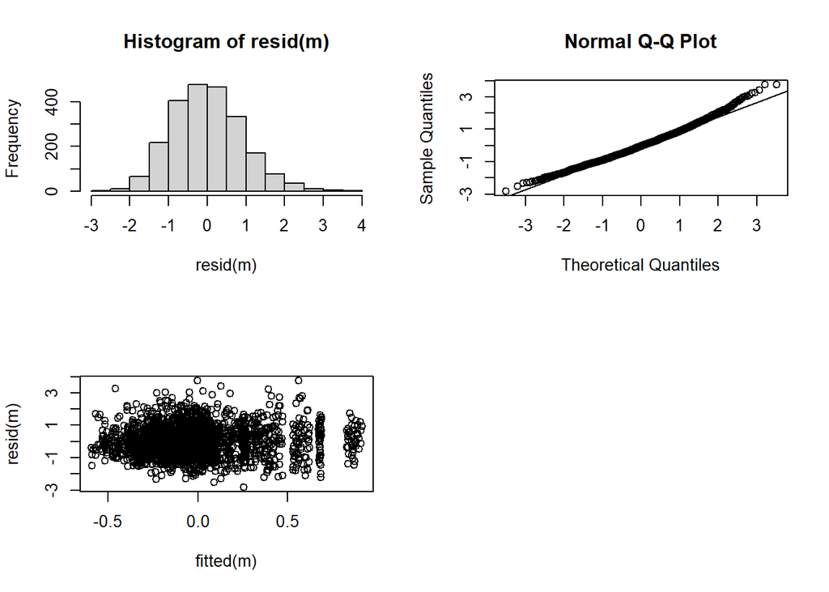

```r
par(mfrow=c(2, 2))
hist(resid(m))
qqnorm(resid(m));qqline(resid(m))
plot(fitted(m), resid(m))
```

#### Temperature effects on f0

During *Lists*, there were no effects of temperature on f0. (Only during *Diapix*)

```
##   f0feature  ROI section direction temperatureAffectsF0   estimate
## 1      f0sd Eyes  Diapix  negative              affects -0.6869556
##                  SE                 t           p correctedP
## 1 0.200187439736363 -3.43156217197648 0.000798551 0.01916522
```

## Convergence

(following Levitan & Hirschberg 2011’s method)

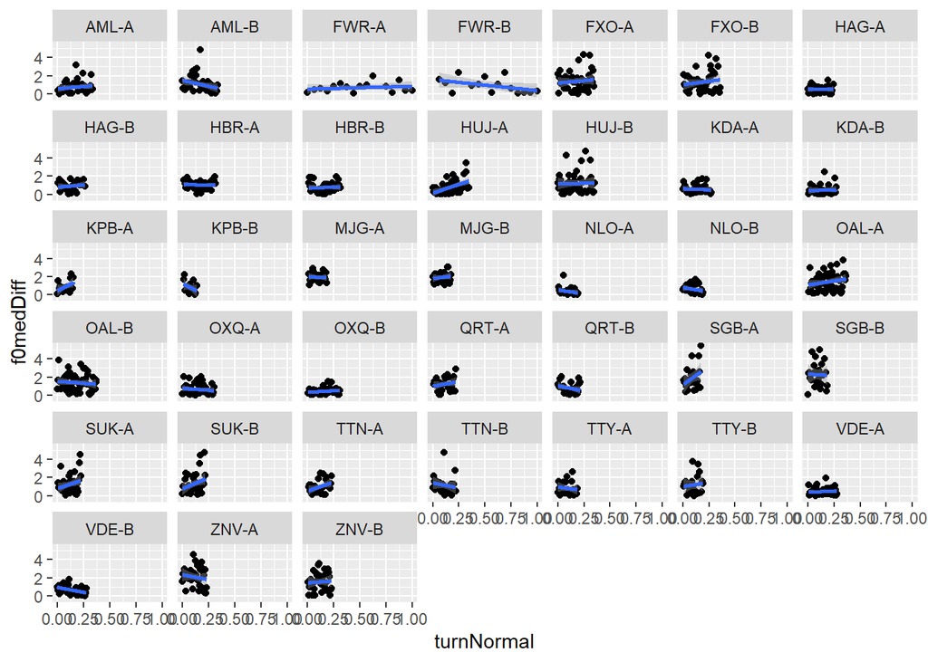

```r
ggplot(dat |> filter(task=="Lists"), aes(turnNormal, f0medDiff))+
  geom_point()+
  geom_smooth(method="lm")+
  facet_wrap(~speaker)
```

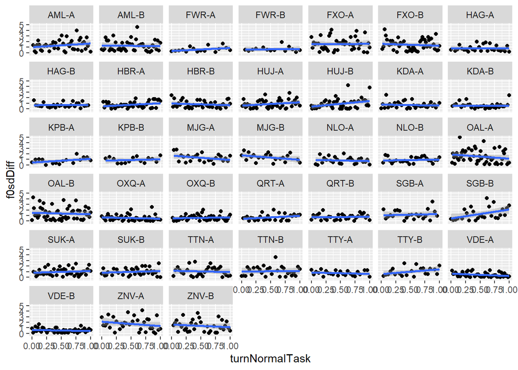

```
##   speaker   direction        coefficient  condition  feature section
## 1   HUJ-A  divergence  0.500424842133659      close f0median   Lists
## 2   VDE-B convergence -0.436894436925545 impersonal f0median   Lists
## 3   VDE-A convergence  -0.31549012844638 impersonal     f0sd   Lists
## 4   SGB-B  divergence  0.438803836732088 impersonal     f0sd   Lists
```

```r
ggplot(dat |> filter(task=="Lists"), aes(turnNormalTask, f0sdDiff))+
  geom_point()+
  geom_smooth(method="lm")+
  facet_wrap(~speaker)
```

# TEMPERATURE ANALYSIS

#### First part of experiment (Lists)

##### Nose

People *increased* their temperature *more often* when they wanted more to *become friends* with their partner. When performing pairwise comparison and adjusting the p value, it became a little over .05 (i.e. .055)

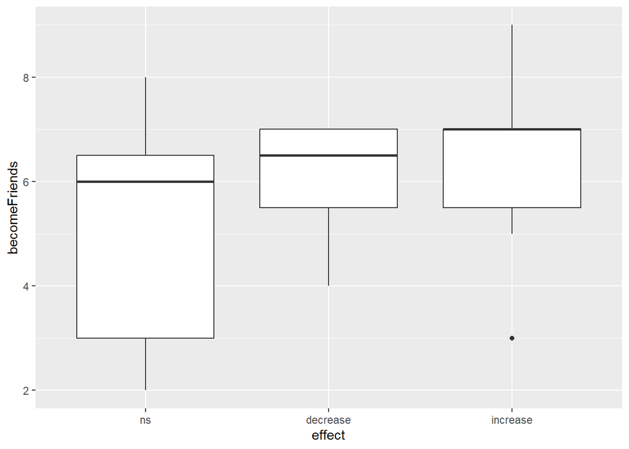

```r
ggplot(d |> filter(ROI=="Nose"), aes(effect, becomeFriends))+
  geom_boxplot()
```

```r
tidy(m <- nnet::multinom(effect ~ becomeFriends, data=d |> filter(ROI=="Nose"))) |>
  as_tibble() |>
  mutate(estimate = plogis(estimate)) # plogis transforms log odds (the output of the model) into probabilities
```

```
## # A tibble: 4 × 6
##   y.level  term          estimate std.error statistic p.value
##   <chr>    <chr>            <dbl>     <dbl>     <dbl>   <dbl>
## 1 decrease (Intercept)     0.0611     2.16     -1.27   0.206
## 2 decrease becomeFriends   0.577      0.359     0.863  0.388
## 3 increase (Intercept)     0.0806     1.53     -1.59   0.111
## 4 increase becomeFriends   0.625      0.255     2.00   0.0454
```

##### Eyes

No significant effects

##### Forehead

No significant effects

##### Cheeks

No significant effects

# SPEECH ANALYSIS

## Speech adaptation (regardless of interlocutor)

### Numerical measure (all speakers together; without Domino task)

#### f0 median

Significant effect

#### f0 SD

Significant effect

#### Temperature effects on f0

Significant effects

## Convergence

Only a couple of significant effects – see above.

# TEMPERATURE ANALYSIS

#### First part of experiment (Lists)

##### Nose

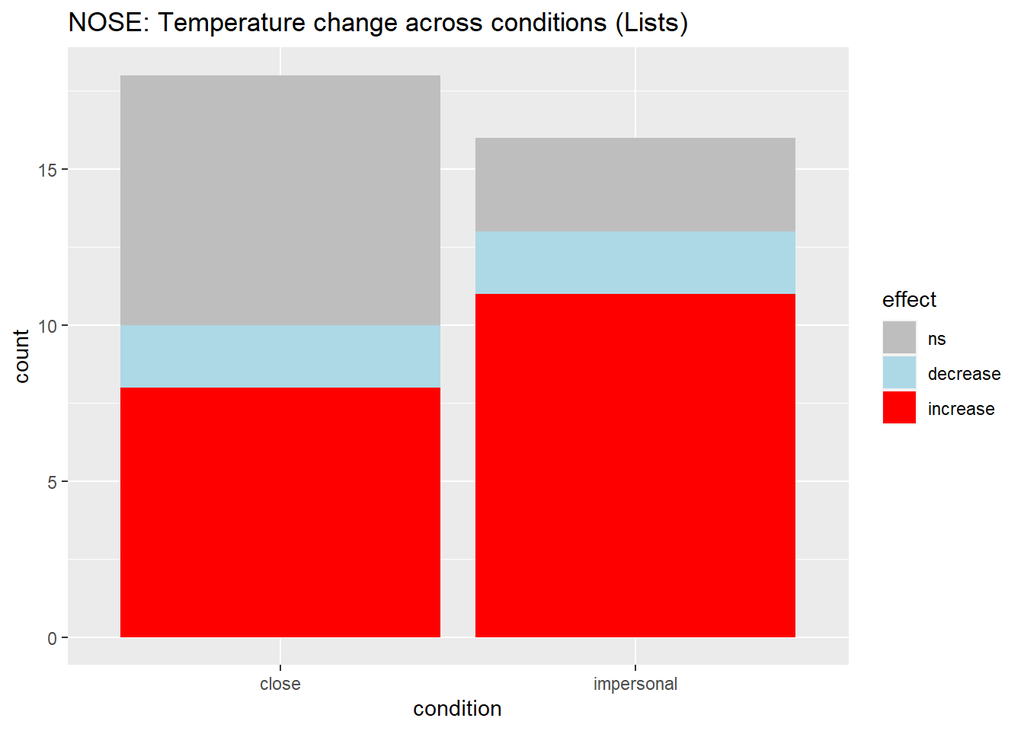

```r
ggplot(d |> filter(ROI=="Nose"), aes(condition, fill=effect))+
  geom_bar()+
  ggtitle("NOSE: Temperature change across conditions (Lists)")+
  scale_fill_manual(values = c("decrease" = "lightblue", "increase" = "red", "ns" = "gray"))
```

No effect of condition

```r
tidy(m <- nnet::multinom(effect ~ condition, data=d |> filter(ROI=="Nose"))) |>
  as_tibble() |>
  mutate(estimate = plogis(estimate)) # plogis transforms log odds (the output of the model) into probabilities
```

```
## # A tibble: 4 × 6
##   y.level  term                estimate std.error   statistic p.value
##   <chr>    <chr>                  <dbl>     <dbl>       <dbl>   <dbl>
## 1 decrease (Intercept)            0.200     0.791 -1.75        0.0795
## 2 decrease conditionimpersonal    0.727     1.21   0.812       0.417
## 3 increase (Intercept)            0.500     0.500  0.00000342  1.00
## 4 increase conditionimpersonal    0.786     0.821  1.58        0.114
```

```r
emmeans(m, pairwise~condition, by="effect")
```

```
## $emmeans
## effect = ns:
##  condition   prob     SE df lower.CL upper.CL
##  close      0.444 0.1171  4   0.1193    0.770
##  impersonal 0.187 0.0976  4  -0.0834    0.458
##
## effect = decrease:
##  condition   prob     SE df lower.CL upper.CL
##  close      0.111 0.0741  4  -0.0946    0.317
##  impersonal 0.125 0.0827  4  -0.1046    0.355
##
## effect = increase:
##  condition   prob     SE df lower.CL upper.CL
##  close      0.444 0.1171  4   0.1193    0.770
##  impersonal 0.688 0.1159  4   0.3658    1.009
##
## Confidence level used: 0.95
##
## $contrasts
## effect = ns:
##  contrast           estimate    SE df t.ratio p.value
##  close - impersonal   0.2569 0.152  4   1.686  0.1672
##
## effect = decrease:
##  contrast           estimate    SE df t.ratio p.value
##  close - impersonal  -0.0139 0.111  4  -0.125  0.9065
##
## effect = increase:
##  contrast           estimate    SE df t.ratio p.value
##  close - impersonal  -0.2431 0.165  4  -1.475  0.2142
```

```r
summary(glmer(sign ~ condition + (1|speaker), d |> filter(ROI=="Nose"), family=binomial))
```

```
## boundary (singular) fit: see help('isSingular')
```

```
## Generalized linear mixed model fit by maximum likelihood (Laplace
##   Approximation) [glmerMod]
##  Family: binomial  ( logit )
## Formula: sign ~ condition + (1 | speaker)
##    Data: filter(d, ROI == "Nose")
##
##      AIC      BIC   logLik deviance df.resid
##     46.2     50.8    -20.1     40.2       31
##
## Scaled residuals:
##     Min      1Q  Median      3Q     Max
## -2.0817 -1.1180  0.4804  0.8944  0.8944
##
## Random effects:
##  Groups  Name        Variance  Std.Dev.
##  speaker (Intercept) 3.735e-10 1.933e-05
## Number of obs: 34, groups:  speaker, 34
##
## Fixed effects:
##                     Estimate Std. Error z value Pr(>|z|)
## (Intercept)           0.2231     0.4743    0.47    0.638
## conditionimpersonal   1.2432     0.7971    1.56    0.119
##
## Correlation of Fixed Effects:
##             (Intr)
## cndtnmprsnl -0.595
## optimizer (Nelder_Mead) convergence code: 0 (OK)
## boundary (singular) fit: see help('isSingular')
```

The null effects of perception of partner

```r
tidy(m <- nnet::multinom(effect ~ closeness, data=d |> filter(ROI=="Nose"))) |>
  as_tibble() |>
  mutate(estimate = plogis(estimate)) # plogis transforms log odds (the output of the model) into probabilities
```

```
## # A tibble: 4 × 6
##   y.level  term        estimate std.error statistic p.value
##   <chr>    <chr>          <dbl>     <dbl>     <dbl>   <dbl>
## 1 decrease (Intercept)    0.282     1.35    -0.692    0.489
## 2 decrease closeness      0.495     0.322   -0.0642   0.949
## 3 increase (Intercept)    0.627     0.881    0.589    0.556
## 4 increase closeness      0.502     0.208    0.0346   0.972
```

```r
tidy(m <- nnet::multinom(effect ~ similarity, data=d |> filter(ROI=="Nose"))) |>
  as_tibble() |>
  mutate(estimate = plogis(estimate)) # plogis transforms log odds (the output of the model) into probabilities
```

```
## # A tibble: 4 × 6
##   y.level  term        estimate std.error statistic p.value
##   <chr>    <chr>          <dbl>     <dbl>     <dbl>   <dbl>
## 1 decrease (Intercept)    0.155     1.96     -0.864   0.388
## 2 decrease similarity     0.531     0.332     0.371   0.711
## 3 increase (Intercept)    0.374     1.27     -0.404   0.686
## 4 increase similarity     0.547     0.218     0.863   0.388
```

```r
tidy(m <- nnet::multinom(effect ~ likeability, data=d |> filter(ROI=="Nose"))) |>
  as_tibble() |>
  mutate(estimate = plogis(estimate)) # plogis transforms log odds (the output of the model) into probabilities
```

```
## # A tibble: 4 × 6
##   y.level  term        estimate std.error statistic p.value
##   <chr>    <chr>          <dbl>     <dbl>     <dbl>   <dbl>
## 1 decrease (Intercept)  0.00183     4.02     -1.57    0.117
## 2 decrease likeability  0.676       0.529     1.39    0.165
## 3 increase (Intercept)  0.302       1.87     -0.449   0.653
## 4 increase likeability  0.551       0.273     0.752   0.452
```

##### Eyes

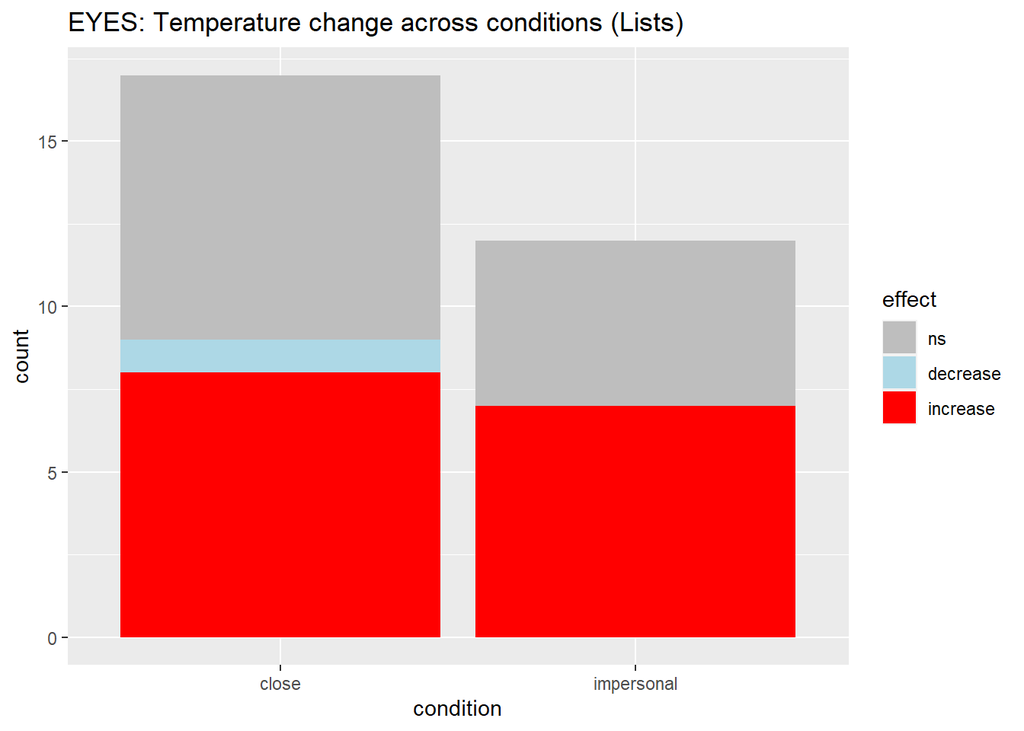

```r
ggplot(d |> filter(ROI=="Eyes"), aes(condition, fill=effect))+
  geom_bar()+
  ggtitle("EYES: Temperature change across conditions (Lists)")+
  scale_fill_manual(values = c("decrease" = "lightblue", "increase" = "red", "ns" = "gray"))
```

No effect of condition

```r
tidy(m <- nnet::multinom(effect ~ condition, data=d |> filter(ROI=="Eyes"))) |>
  as_tibble() |>
  mutate(estimate = plogis(estimate)) # plogis transforms log odds (the output of the model) into probabilities
```

```
## # A tibble: 4 × 6
##   y.level  term                estimate std.error statistic p.value
##   <chr>    <chr>                  <dbl>     <dbl>     <dbl>   <dbl>
## 1 decrease (Intercept)         0.111        1.06  -1.96      0.0499
## 2 decrease conditionimpersonal 0.000518    55.6   -0.136     0.892
## 3 increase (Intercept)         0.500        0.500  0.000103  1.00
## 4 increase conditionimpersonal 0.583        0.770  0.437     0.662
```

```r
emmeans(m, pairwise~condition, by="effect")
```

```
## $emmeans
## effect = ns:
##  condition      prob     SE df lower.CL upper.CL
##  close      0.470588 0.1211  4  0.13448  0.80670
##  impersonal 0.416645 0.1423  4  0.02151  0.81178
##
## effect = decrease:
##  condition      prob     SE df lower.CL upper.CL
##  close      0.058800 0.0571  4 -0.09961  0.21721
##  impersonal 0.000027 0.0015  4 -0.00414  0.00419
##
## effect = increase:
##  condition      prob     SE df lower.CL upper.CL
##  close      0.470612 0.1211  4  0.13450  0.80672
##  impersonal 0.583328 0.1423  4  0.18819  0.97847
##
## Confidence level used: 0.95
##
## $contrasts
## effect = ns:
##  contrast           estimate     SE df t.ratio p.value
##  close - impersonal   0.0539 0.1868  4   0.289  0.7871
##
## effect = decrease:
##  contrast           estimate     SE df t.ratio p.value
##  close - impersonal   0.0588 0.0571  4   1.030  0.3613
##
## effect = increase:
##  contrast           estimate     SE df t.ratio p.value
##  close - impersonal  -0.1127 0.1868  4  -0.603  0.5789
```

```r
summary(glmer(sign ~ condition + (1|speaker), d |> filter(ROI=="Eyes"), family=binomial))
```

```
## boundary (singular) fit: see help('isSingular')
```

```
## Generalized linear mixed model fit by maximum likelihood (Laplace
##   Approximation) [glmerMod]
##  Family: binomial  ( logit )
## Formula: sign ~ condition + (1 | speaker)
##    Data: filter(d, ROI == "Eyes")
##
##      AIC      BIC   logLik deviance df.resid
##     45.8     49.9    -19.9     39.8       26
##
## Scaled residuals:
##     Min      1Q  Median      3Q     Max
## -1.1832 -1.0607  0.8451  0.9428  0.9428
##
## Random effects:
##  Groups  Name        Variance Std.Dev.
##  speaker (Intercept) 5.95e-11 7.714e-06
## Number of obs: 29, groups:  speaker, 29
##
## Fixed effects:
##                     Estimate Std. Error z value Pr(>|z|)
## (Intercept)           0.1178     0.4859   0.242    0.808
## conditionimpersonal   0.2187     0.7609   0.287    0.774
##
## Correlation of Fixed Effects:
##             (Intr)
## cndtnmprsnl -0.639
## optimizer (Nelder_Mead) convergence code: 0 (OK)
## boundary (singular) fit: see help('isSingular')
```

No effect of the perception of their partner.

```r
tidy(m <- nnet::multinom(effect ~ becomeFriends, data=d |> filter(ROI=="Eyes"))) |>
  as_tibble() |>
  mutate(estimate = plogis(estimate)) # plogis transforms log odds (the output of the model) into probabilities
```

```
## # A tibble: 4 × 6
##   y.level  term          estimate std.error statistic p.value
##   <chr>    <chr>            <dbl>     <dbl>     <dbl>   <dbl>
## 1 decrease (Intercept)   4.83e-32    87.3      -0.826   0.409
## 2 decrease becomeFriends 1.00e+ 0    10.2       0.832   0.405
## 3 increase (Intercept)   6.73e- 1     1.60      0.451   0.652
## 4 increase becomeFriends 4.76e- 1     0.258    -0.375   0.707
```

```r
tidy(m <- nnet::multinom(effect ~ closeness, data=d |> filter(ROI=="Eyes"))) |>
  as_tibble() |>
  mutate(estimate = plogis(estimate)) # plogis transforms log odds (the output of the model) into probabilities
```

```
## # A tibble: 4 × 6
##   y.level  term        estimate std.error statistic p.value
##   <chr>    <chr>          <dbl>     <dbl>     <dbl>   <dbl>
## 1 decrease (Intercept)  0.00292     3.96     -1.47    0.141
## 2 decrease closeness    0.659       0.655     1.00    0.315
## 3 increase (Intercept)  0.622       0.868     0.574   0.566
## 4 increase closeness    0.476       0.211    -0.456   0.649
```

```r
tidy(m <- nnet::multinom(effect ~ similarity, data=d |> filter(ROI=="Eyes"))) |>
  as_tibble() |>
  mutate(estimate = plogis(estimate)) # plogis transforms log odds (the output of the model) into probabilities
```

```
## # A tibble: 4 × 6
##   y.level  term          estimate std.error statistic p.value
##   <chr>    <chr>            <dbl>     <dbl>     <dbl>   <dbl>
## 1 decrease (Intercept) 0.00000491    10.3     -1.19     0.236
## 2 decrease similarity  0.792          1.30     1.03     0.302
## 3 increase (Intercept) 0.557          1.29     0.176    0.860
## 4 increase similarity  0.496          0.212   -0.0682   0.946
```

```r
tidy(m <- nnet::multinom(effect ~ likeability, data=d |> filter(ROI=="Eyes"))) |>
  as_tibble() |>
  mutate(estimate = plogis(estimate)) # plogis transforms log odds (the output of the model) into probabilities
```

```
## # A tibble: 4 × 6
##   y.level  term        estimate std.error statistic p.value
##   <chr>    <chr>          <dbl>     <dbl>     <dbl>   <dbl>
## 1 decrease (Intercept) 5.12e-14    26.3       -1.16   0.245
## 2 decrease likeability 9.67e- 1     2.98       1.13   0.258
## 3 increase (Intercept) 9.11e- 1     2.14       1.08   0.278
## 4 increase likeability 4.22e- 1     0.303     -1.04   0.297
```

##### Forehead

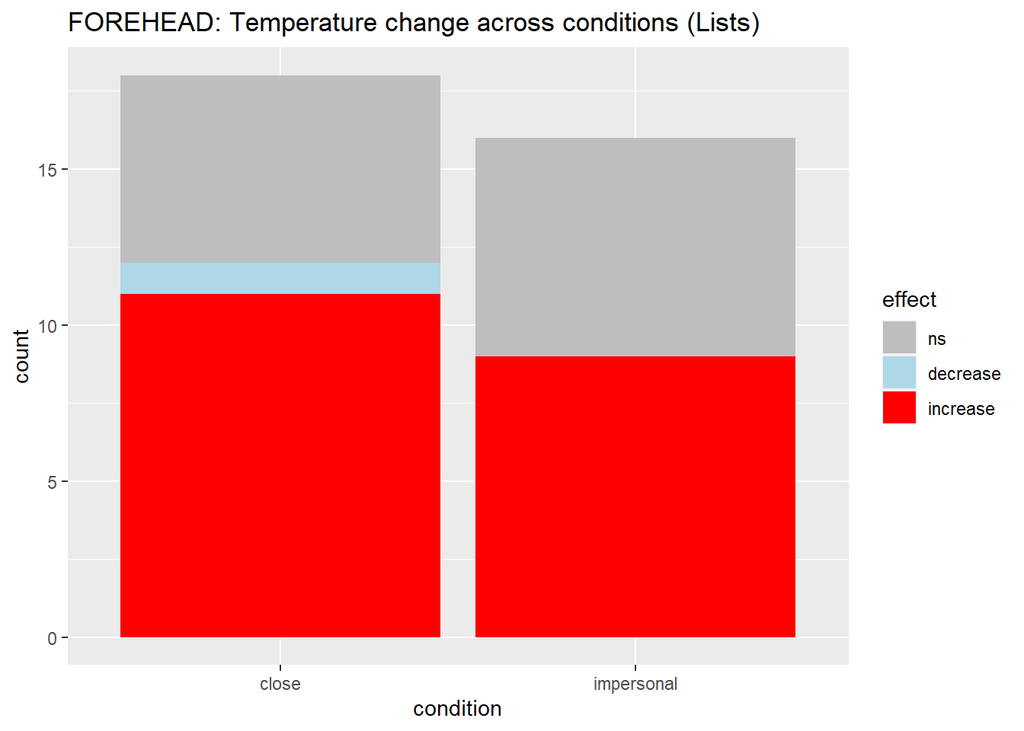

```r
ggplot(d |> filter(ROI=="Forehead"), aes(condition, fill=effect))+
  geom_bar()+
  ggtitle("FOREHEAD: Temperature change across conditions (Lists)")+
  scale_fill_manual(values = c("decrease" = "lightblue", "increase" = "red", "ns" = "gray"))
```

No effect of condition

```r
tidy(m <- nnet::multinom(effect ~ condition, data=d |> filter(ROI=="Forehead"))) |>
  as_tibble() |>
  mutate(estimate = plogis(estimate)) # plogis transforms log odds (the output of the model) into probabilities
```

```
## # A tibble: 4 × 6
##   y.level  term                estimate std.error statistic p.value
##   <chr>    <chr>                  <dbl>     <dbl>     <dbl>   <dbl>
## 1 decrease (Intercept)         0.143        1.08     -1.66   0.0971
## 2 decrease conditionimpersonal 0.000219    62.5      -0.135  0.893
## 3 increase (Intercept)         0.647        0.508     1.19   0.232
## 4 increase conditionimpersonal 0.412        0.715    -0.496  0.620
```

```r
emmeans(m, pairwise~condition, by="effect")
```

```
## $emmeans
## effect = ns:
##  condition      prob       SE df lower.CL upper.CL
##  close      0.333327 0.111111  4  0.02483  0.64182
##  impersonal 0.437446 0.124018  4  0.09312  0.78178
##
## effect = decrease:
##  condition      prob       SE df lower.CL upper.CL
##  close      0.055540 0.053983  4 -0.09434  0.20542
##  impersonal 0.000016 0.000999  4 -0.00276  0.00279
##
## effect = increase:
##  condition      prob       SE df lower.CL upper.CL
##  close      0.611134 0.114903  4  0.29211  0.93016
##  impersonal 0.562538 0.124018  4  0.21821  0.90687
##
## Confidence level used: 0.95
##
## $contrasts
## effect = ns:
##  contrast           estimate    SE df t.ratio p.value
##  close - impersonal  -0.1041 0.167  4  -0.625  0.5657
##
## effect = decrease:
##  contrast           estimate    SE df t.ratio p.value
##  close - impersonal   0.0555 0.054  4   1.028  0.3619
##
## effect = increase:
##  contrast           estimate    SE df t.ratio p.value
##  close - impersonal   0.0486 0.169  4   0.287  0.7881
```

```r
summary(glmer(sign ~ condition + (1|speaker), d |> filter(ROI=="Forehead"), family=binomial))
```

```
## boundary (singular) fit: see help('isSingular')
```

```
## Generalized linear mixed model fit by maximum likelihood (Laplace
##   Approximation) [glmerMod]
##  Family: binomial  ( logit )
## Formula: sign ~ condition + (1 | speaker)
##    Data: filter(d, ROI == "Forehead")
##
##      AIC      BIC   logLik deviance df.resid
##     50.8     55.4    -22.4     44.8       31
##
## Scaled residuals:
##     Min      1Q  Median      3Q     Max
## -1.4142 -1.1339  0.7071  0.8382  0.8819
##
## Random effects:
##  Groups  Name        Variance Std.Dev.
##  speaker (Intercept) 5.83e-11 7.636e-06
## Number of obs: 34, groups:  speaker, 34
##
## Fixed effects:
##                     Estimate Std. Error z value Pr(>|z|)
## (Intercept)           0.6931     0.5000   1.386    0.166
## conditionimpersonal  -0.4418     0.7099  -0.622    0.534
##
## Correlation of Fixed Effects:
##             (Intr)
## cndtnmprsnl -0.704
## optimizer (Nelder_Mead) convergence code: 0 (OK)
## boundary (singular) fit: see help('isSingular')
```

No effect of the perception of their partner.

```r
tidy(m <- nnet::multinom(effect ~ becomeFriends, data=d |> filter(ROI=="Forehead"))) |>
  as_tibble() |>
  mutate(estimate = plogis(estimate)) # plogis transforms log odds (the output of the model) into probabilities
```

```
## # A tibble: 4 × 6
##   y.level  term          estimate std.error statistic p.value
##   <chr>    <chr>            <dbl>     <dbl>     <dbl>   <dbl>
## 1 decrease (Intercept)    0.00597     5.45     -0.939   0.348
## 2 decrease becomeFriends  0.595       0.769     0.502   0.616
## 3 increase (Intercept)    0.765       1.34      0.878   0.380
## 4 increase becomeFriends  0.469       0.215    -0.582   0.560
```

```r
tidy(m <- nnet::multinom(effect ~ closeness, data=d |> filter(ROI=="Forehead"))) |>
  as_tibble() |>
  mutate(estimate = plogis(estimate)) # plogis transforms log odds (the output of the model) into probabilities
```

```
## # A tibble: 4 × 6
##   y.level  term        estimate std.error statistic p.value
##   <chr>    <chr>          <dbl>     <dbl>     <dbl>   <dbl>
## 1 decrease (Intercept)    0.230     2.28     -0.531   0.596
## 2 decrease closeness      0.405     0.658    -0.582   0.560
## 3 increase (Intercept)    0.736     0.858     1.19    0.233
## 4 increase closeness      0.462     0.197    -0.770   0.441
```

```r
tidy(m <- nnet::multinom(effect ~ similarity, data=d |> filter(ROI=="Forehead"))) |>
  as_tibble() |>
  mutate(estimate = plogis(estimate)) # plogis transforms log odds (the output of the model) into probabilities
```

```
## # A tibble: 4 × 6
##   y.level  term        estimate std.error statistic p.value
##   <chr>    <chr>          <dbl>     <dbl>     <dbl>   <dbl>
## 1 decrease (Intercept)  0.00311     5.21    -1.11     0.268
## 2 decrease similarity   0.623       0.736    0.680    0.496
## 3 increase (Intercept)  0.603       1.20     0.347    0.729
## 4 increase similarity   0.501       0.202    0.0122   0.990
```

```r
tidy(m <- nnet::multinom(effect ~ likeability, data=d |> filter(ROI=="Forehead"))) |>
  as_tibble() |>
  mutate(estimate = plogis(estimate)) # plogis transforms log odds (the output of the model) into probabilities
```

```
## # A tibble: 4 × 6
##   y.level  term        estimate std.error statistic p.value
##   <chr>    <chr>          <dbl>     <dbl>     <dbl>   <dbl>
## 1 decrease (Intercept) 0.000264     8.43     -0.977   0.329
## 2 decrease likeability 0.680        1.05      0.717   0.474
## 3 increase (Intercept) 0.666        1.80      0.384   0.701
## 4 increase likeability 0.491        0.255    -0.147   0.883
```

##### Cheeks

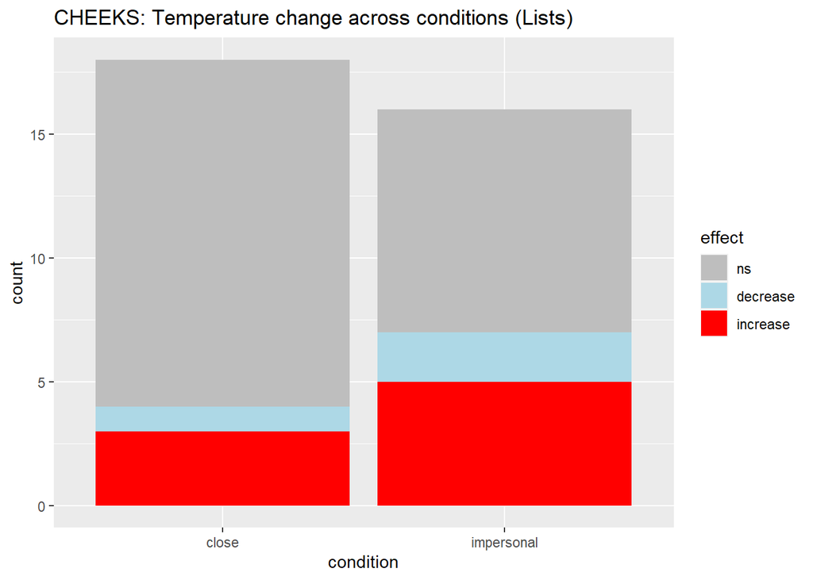

```r
ggplot(d |> filter(ROI=="Cheeks"), aes(condition, fill=effect))+
  geom_bar()+
  ggtitle("CHEEKS: Temperature change across conditions (Lists)")+
  scale_fill_manual(values = c("decrease" = "lightblue", "increase" = "red", "ns" = "gray"))
```

No effect of condition

```r
tidy(m <- nnet::multinom(effect ~ condition, data=d |> filter(ROI=="Cheeks"))) |>
  as_tibble() |>
  mutate(estimate = plogis(estimate)) # plogis transforms log odds (the output of the model) into probabilities
```

```
## # A tibble: 4 × 6
##   y.level  term                estimate std.error statistic p.value
##   <chr>    <chr>                  <dbl>     <dbl>     <dbl>   <dbl>
## 1 decrease (Intercept)           0.0667     1.04     -2.55   0.0108
## 2 decrease conditionimpersonal   0.757      1.30      0.875  0.382
## 3 increase (Intercept)           0.176      0.636    -2.42   0.0155
## 4 increase conditionimpersonal   0.722      0.846     1.13   0.260
```

```r
emmeans(m, pairwise~condition, by="effect")
```

```
## $emmeans
## effect = ns:
##  condition    prob     SE df lower.CL upper.CL
##  close      0.7778 0.0980  4  0.50571    1.050
##  impersonal 0.5625 0.1240  4  0.21817    0.907
##
## effect = decrease:
##  condition    prob     SE df lower.CL upper.CL
##  close      0.0556 0.0540  4 -0.09435    0.205
##  impersonal 0.1250 0.0827  4 -0.10456    0.355
##
## effect = increase:
##  condition    prob     SE df lower.CL upper.CL
##  close      0.1667 0.0878  4 -0.07722    0.411
##  impersonal 0.3125 0.1159  4 -0.00923    0.634
##
## Confidence level used: 0.95
##
## $contrasts
## effect = ns:
##  contrast           estimate     SE df t.ratio p.value
##  close - impersonal   0.2153 0.1581  4   1.362  0.2449
##
## effect = decrease:
##  contrast           estimate     SE df t.ratio p.value
##  close - impersonal  -0.0694 0.0987  4  -0.703  0.5207
##
## effect = increase:
##  contrast           estimate     SE df t.ratio p.value
##  close - impersonal  -0.1458 0.1454  4  -1.003  0.3727
```

```r
summary(m <- glmer(sign ~ condition + (1|speaker), d |> filter(ROI=="Cheeks"), family=binomial))
```

```
## boundary (singular) fit: see help('isSingular')
```

```
## Generalized linear mixed model fit by maximum likelihood (Laplace
##   Approximation) [glmerMod]
##  Family: binomial  ( logit )
## Formula: sign ~ condition + (1 | speaker)
##    Data: filter(d, ROI == "Cheeks")
##
##      AIC      BIC   logLik deviance df.resid
##     47.0     51.6    -20.5     41.0       31
##
## Scaled residuals:
##     Min      1Q  Median      3Q     Max
## -0.8819 -0.7951 -0.5345  1.1339  1.8708
##
## Random effects:
##  Groups  Name        Variance  Std.Dev.
##  speaker (Intercept) 7.206e-13 8.489e-07
## Number of obs: 34, groups:  speaker, 34
##
## Fixed effects:
##                     Estimate Std. Error z value Pr(>|z|)
## (Intercept)          -1.2528     0.5669   -2.21   0.0271 *
## conditionimpersonal   1.0014     0.7585    1.32   0.1868
## ---
## Signif. codes:  0 '***' 0.001 '**' 0.01 '*' 0.05 '.' 0.1 ' ' 1
##
## Correlation of Fixed Effects:
##             (Intr)
## cndtnmprsnl -0.747
## optimizer (Nelder_Mead) convergence code: 0 (OK)
## boundary (singular) fit: see help('isSingular')
```

No effect of the perception of their partner.

```r
tidy(m <- nnet::multinom(effect ~ becomeFriends, data=d |> filter(ROI=="Cheeks"))) |>
  as_tibble() |>
  mutate(estimate = plogis(estimate)) # plogis transforms log odds (the output of the model) into probabilities
```

```
## # A tibble: 4 × 6
##   y.level  term          estimate std.error statistic p.value
##   <chr>    <chr>            <dbl>     <dbl>     <dbl>   <dbl>
## 1 decrease (Intercept)      0.136     2.27    -0.815    0.415
## 2 decrease becomeFriends    0.492     0.364   -0.0847   0.932
## 3 increase (Intercept)      0.463     1.42    -0.103    0.918
## 4 increase becomeFriends    0.461     0.237   -0.655    0.512
```

```r
tidy(m <- nnet::multinom(effect ~ closeness, data=d |> filter(ROI=="Cheeks"))) |>
  as_tibble() |>
  mutate(estimate = plogis(estimate)) # plogis transforms log odds (the output of the model) into probabilities
```

```
## # A tibble: 4 × 6
##   y.level  term        estimate std.error  statistic p.value
##   <chr>    <chr>          <dbl>     <dbl>      <dbl>   <dbl>
## 1 decrease (Intercept)    0.338     1.38  -0.487       0.626
## 2 decrease closeness      0.405     0.396 -0.973       0.331
## 3 increase (Intercept)    0.500     0.960  0.0000900   1.00
## 4 increase closeness      0.429     0.250 -1.15        0.250
```

```r
tidy(m <- nnet::multinom(effect ~ similarity, data=d |> filter(ROI=="Cheeks"))) |>
  as_tibble() |>
  mutate(estimate = plogis(estimate)) # plogis transforms log odds (the output of the model) into probabilities
```

```
## # A tibble: 4 × 6
##   y.level  term        estimate std.error statistic p.value
##   <chr>    <chr>          <dbl>     <dbl>     <dbl>   <dbl>
## 1 decrease (Intercept)   0.0626     2.48     -1.09   0.275
## 2 decrease similarity    0.527      0.381     0.284  0.777
## 3 increase (Intercept)   0.826      1.40      1.11   0.268
## 4 increase similarity    0.380      0.266    -1.84   0.0652
```

```r
tidy(m <- nnet::multinom(effect ~ likeability, data=d |> filter(ROI=="Cheeks"))) |>
  as_tibble() |>
  mutate(estimate = plogis(estimate)) # plogis transforms log odds (the output of the model) into probabilities
```

```
## # A tibble: 4 × 6
##   y.level  term        estimate std.error statistic p.value
##   <chr>    <chr>          <dbl>     <dbl>     <dbl>   <dbl>
## 1 decrease (Intercept) 0.000404     5.20     -1.50    0.133
## 2 decrease likeability 0.682        0.652     1.17    0.241
## 3 increase (Intercept) 0.820        2.01      0.757   0.449
## 4 increase likeability 0.404        0.303    -1.28    0.200
```